# Titanic histogram and violin plot

Saixiong Han

October 19, 2016

## Training Data Processing

This part we imported train data into R. On account of later processing, I added two character data for Surviving and Pclass attributes. After calculting the missing data in the dataset,I choose the data without missing value into a new dataset.

```r
train<-read.csv('F:/GraduateStudy/2016Fall/DatAna/Assignment/3/train_s.csv',stringsAsFactors=F)
str(train)
```

```
## 'data.frame':    891 obs. of  14 variables:
##  $ PassengerId: int  1 2 3 4 5 6 7 8 9 10 ...
##  $ Survived   : int  0 1 1 1 0 0 0 0 1 1 ...
##  $ Pclass     : int  3 1 3 1 3 3 1 3 3 2 ...
##  $ Name       : chr  "Braund, Mr. Owen Harris" "Cumings, Mrs. John Bradley (Florence Briggs Thayer)" "Heikkinen, Miss. Laina" "Futrelle, Mrs. Jacques Heath (Lily May Peel)" ...
##  $ Sex        : chr  "male" "female" "female" "female" ...
##  $ Age        : num  22 38 26 35 35 NA 54 2 27 14 ...
##  $ SibSp      : int  1 1 0 1 0 0 0 3 0 1 ...
##  $ Parch      : int  0 0 0 0 0 0 0 1 2 0 ...
##  $ Ticket     : chr  "A/5 21171" "PC 17599" "STON/O2. 3101282" "113803" ...
##  $ Fare       : num  7.25 71.28 7.92 53.1 8.05 ...
##  $ Cabin      : chr  "" "C85" "" "C123" ...
##  $ Embarked   : chr  "S" "C" "S" "S" ...
##  $ Survived_s : chr  "N" "Y" "Y" "Y" ...
##  $ Pclass_s   : chr  "3rd" "1st" "3rd" "1st" ...
```

import and view data

```r
train1=train[complete.cases(train),]
summary(train1)
```

```
##   PassengerId       Survived          Pclass          Name
##  Min.   :  1.0   Min.   :0.0000   Min.   :1.000   Length:714
##  1st Qu.:222.2   1st Qu.:0.0000   1st Qu.:1.000   Class :character
##  Median :445.0   Median :0.0000   Median :2.000   Mode  :character
##  Mean   :448.6   Mean   :0.4062   Mean   :2.237
##  3rd Qu.:677.8   3rd Qu.:1.0000   3rd Qu.:3.000
##  Max.   :891.0   Max.   :1.0000   Max.   :3.000
##      Sex                 Age            SibSp            Parch
##  Length:714         Min.   : 0.42   Min.   :0.0000   Min.   :0.0000
##  Class :character   1st Qu.:20.12   1st Qu.:0.0000   1st Qu.:0.0000
##  Mode  :character   Median :28.00   Median :0.0000   Median :0.0000
##                     Mean   :29.70   Mean   :0.5126   Mean   :0.4314
##                     3rd Qu.:38.00   3rd Qu.:1.0000   3rd Qu.:1.0000
##                     Max.   :80.00   Max.   :5.0000   Max.   :6.0000
##     Ticket               Fare           Cabin             Embarked
##  Length:714         Min.   :  0.00   Length:714         Length:714
##  Class :character   1st Qu.:  8.05   Class :character   Class :character
##  Mode  :character   Median : 15.74   Mode  :character   Mode  :character
##                     Mean   : 34.69
##                     3rd Qu.: 33.38
##                     Max.   :512.33
##   Survived_s          Pclass_s
##  Length:714         Length:714
##  Class :character   Class :character
##  Mode  :character   Mode  :character
##
##
##
```

create a new dataset without missing data and get the summary

## Analyze single factor

calculate single factor importance in surviving. The tables below show the most important factors in surviving.

## -Pclass

```
## , ,  = 0
##
##
##            1   2   3
##   female   3   6  55
##   male    61  84 215
##
## , ,  = 1
##
##
##            1   2   3
##   female  82  68  47
##   male    40  15  38
```

The female survived in the Titanic most from first and second class, the number of female in the first and second class died in Titanic is less than 10. This is a very important factor.

## -Parch

```
## , ,  = 0
##
##
##            0   1   2   3   4   5   6
##   female  33  11  13   1   2   3   1
##   male   302  38  16   1   2   1   0
##
## , ,  = 1
##
##
##            0   1   2   3   4   5   6
##   female 120  44  29   3   0   1   0
##   male    66  17  10   0   0   0   0
```

Women without any children or parents are more likely to survive While the more parch they have, the less probability they can survive.

## -SibSp

```
## , ,  = 0
##
##
##            0   1   2   3   4   5
##   female  29  23   3   4   4   1
##   male   267  63  11   4  11   4
##
## , ,  = 1
##
##
##            0   1   2   3   4   5
##   female 115  67   9   4   2   0
##   male    60  30   2   0   1   0
```

Women without any siblings or spouses are more likely to survive. While the more siblings they have, the less probability they can survive.

## -Title

```
## , ,  = 0
##
##
##           Capt  Col  Don  Dr  Jonkheer  Lady  Major  Master  Miss  Mlle
##   female     0    0    0   0         0     0      0       0    41     0
##   male       1    1    1   3         1     0      1      15     0     0
##
##           Mme  Mr  Mrs  Ms  Rev  Sir  the Countess
##   female    0   0   23   0    0    0             0
##   male      0 331    0   0    6    0             0
##
## , ,  = 1
##
##
##           Capt  Col  Don  Dr  Jonkheer  Lady  Major  Master  Miss  Mlle
##   female     0    0    0   1         0     1      0       0   105     2
##   male       0    1    0   2         0     0      1      21     0     0
##
##           Mme  Mr  Mrs  Ms  Rev  Sir  the Countess
##   female    1   0   85   1    0    0             1
##   male      0  67    0   0    0    1             0
```

The survived unmarried women is more than married women, which is accor1dance with the result about SibSp. Generally, the number of women survived is more than the women died.

## Data visualization

data(train1) head(train1)

## -Pclass,Survived,Age and Fare Scatter plot

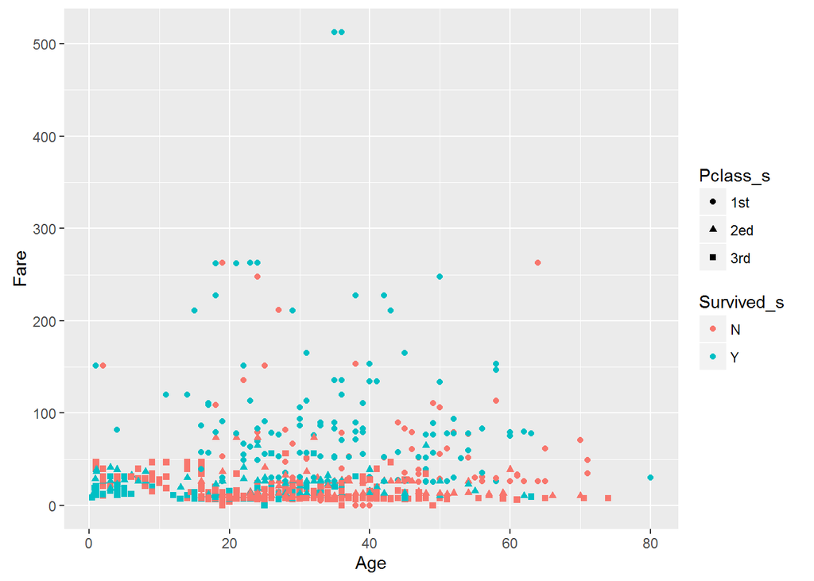

This scatter plot shows there is no linear relation between age and fare. From the color scatter we can see, blue points are mostly on the top wihle the red points are maily on the bottom. That means the higher fare is, the more chances for surviving. It also can be shown in the shape of different classes. The first and second class get more chances for surviving compared to the third class.

## -Sex,Survived,Age and Fare Sctter plot

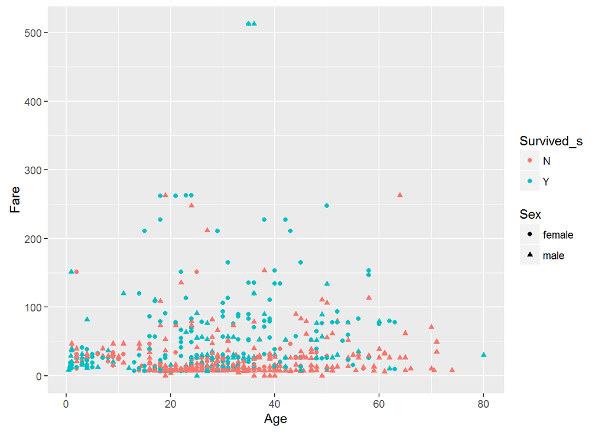

## -Age Histogram

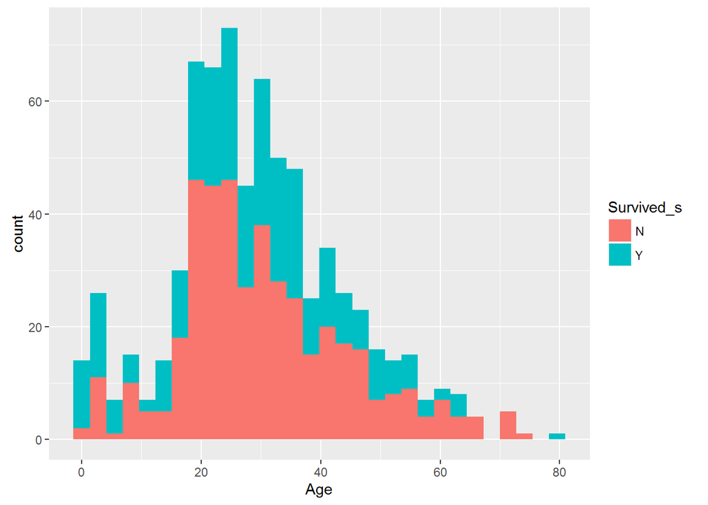

## -Fare Histogram

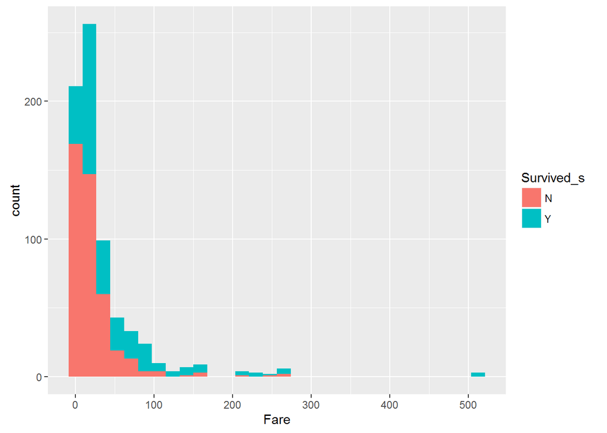

## -Family Size Bar Plot

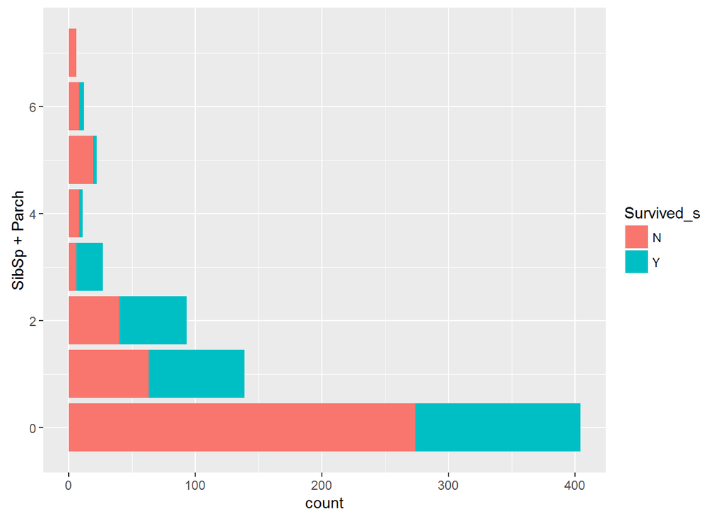

## -Fare,Sex and Survived Box Plot

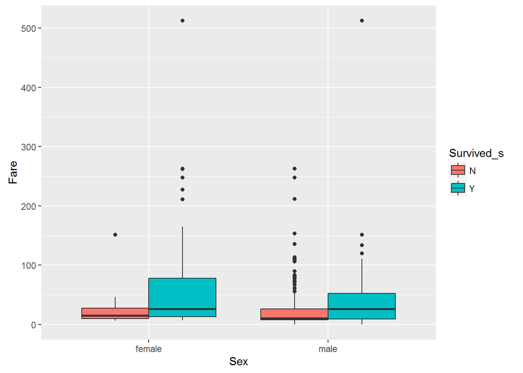

## -Fare,Pclass and Survived Box Plot

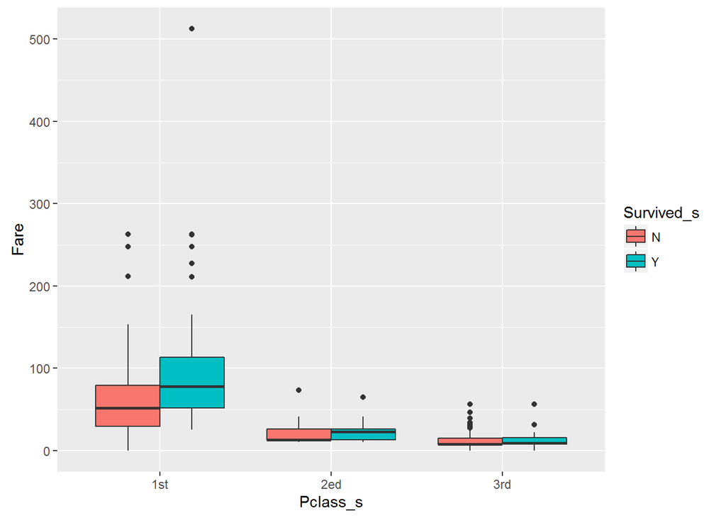

The charts shows that the fare in the first class has larger range than the second and third class. The median of survived people in first class is equal to the upper quartier of dead people. Generally, people in the first class with higher fare have more chance to survive. The upper whisker of second and third class are almost equal to the lower quartier of first class. The fare distribution of second and third class are more intensive than the first class.

## -Age,Pclass and Survived Violin Plot

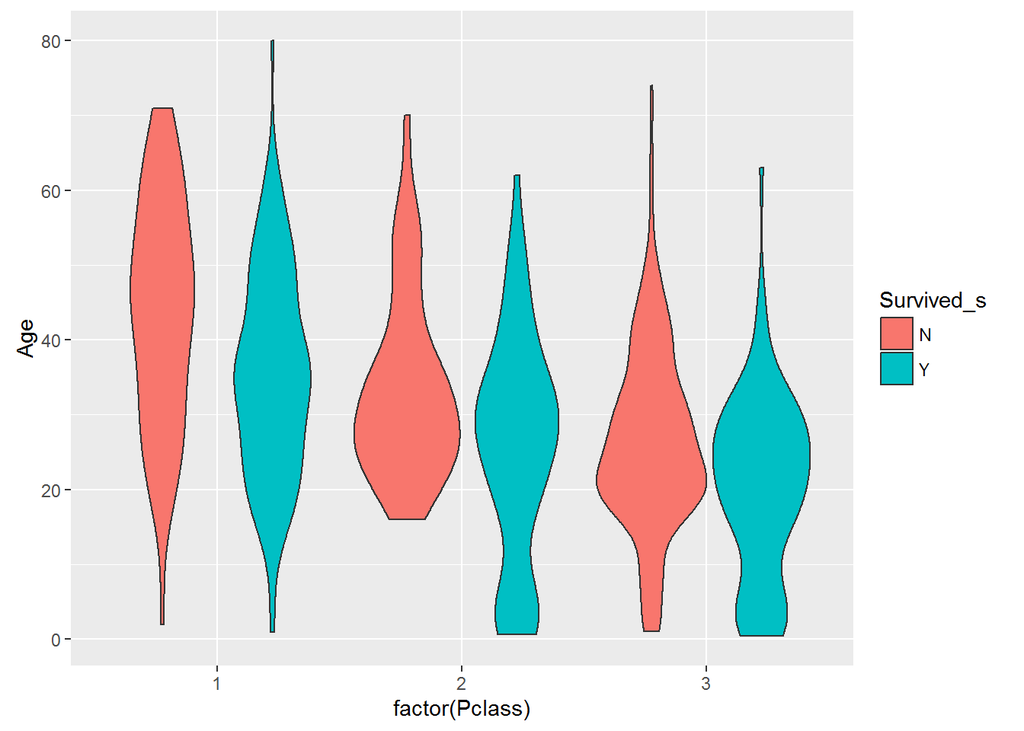

In the first class, most of survived people are around 35 years old and its range is very wide. The distribution of the first class is even, no obvious concentrated trend. In the second class, there is obvious concentrated trend at around 30 year old. That shows most people are aronud 30 years old. The distribution of dead people’s age is a little higher than survived people. The concentrated trend at 20 year old in the third class is also very obvious. The survived people in third class are younger than the dead people.

## -Age,Sex andI Survived Violin Plot

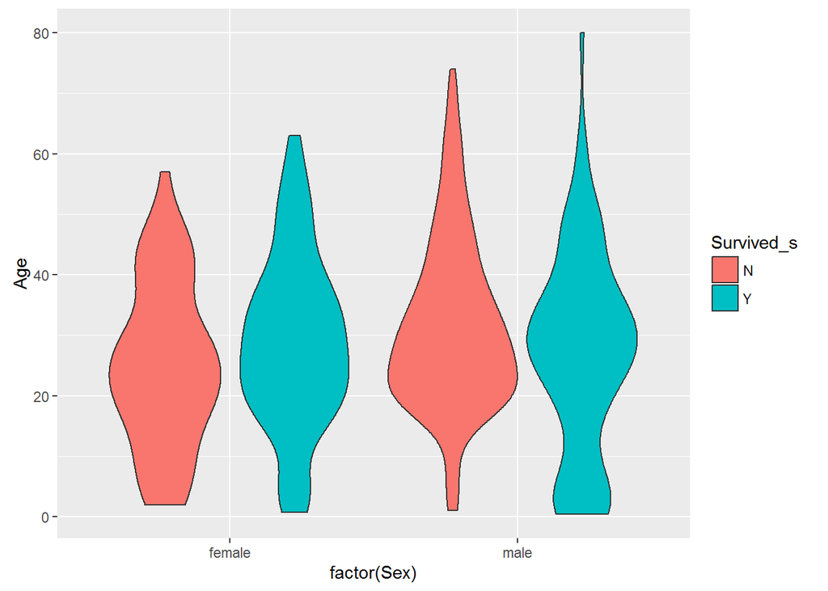

The distribution of male is wider than female generally. Most survived women are around 20 to 30 years old.The distribution of other women at other age is tend to be uniform. The survived men’s age is concentrated in 30 years old. The distribution of other age is not uniform but extremely few.